# Praktikum 3 Anreg

# Data

```r
library(readxl)
dt <- read_xlsx("Data Anreg Praktikum.xlsx", sheet="Data analisis")
dt
```

```
## # A tibble: 34 × 8
##    Provinsi      Kepemilikan_Rumah PDRB_harga_berlaku Consumer_Price_Index   TPT
##    <chr>                     <dbl>              <dbl>                <dbl> <dbl>
##  1 Aceh                       85.2            257502.                 110.  5.64
##  2 Sumatera Uta…              73.2           1236194.                 109.  5.32
##  3 Sumatera Bar…              73.0            352189.                 109.  5.62
##  4 Riau                       78.7           1201384.                 109.  4.16
##  5 Jambi                      89.4            349663.                 108.  4.26
##  6 Sumatera Sel…              85.9            720205.                 109.  3.69
##  7 Bengkulu                   90.5            111829.                 107.  3.41
##  8 Lampung                    92.9            523847.                 109.  4.21
##  9 Kep. Bangka …              89.7            116812.                 105.  4.45
## 10 Kepulauan Ri…              75.4            381730.                 109.  6.45
## # ℹ 24 more rows
## # ℹ 3 more variables: `Urbanisasi\r\n` <dbl>, Gini_Ratio <dbl>,
## #   `Rata-rata_Lama_Sekolah` <dbl>
```

```r
y <- dt$"Kepemilikan_Rumah"
x <- dt$"Rata-rata_Lama_Sekolah"
n <- length(y)
```

```r
dt <- data.frame(cbind(y,x))
head(dt)
```

```
##       y     x
## 1 85.21 10.42
## 2 73.16 10.29
## 3 73.02 10.03
## 4 78.69  9.80
## 5 89.38  9.32
## 6 85.93  9.28
```

# Model

```r
model <- lm(y~x, dt)
summary(model)
```

```
##
## Call:
## lm(formula = y ~ x, data = dt)
##
## Residuals:
##      Min       1Q   Median       3Q      Max
## -14.1596  -2.8438   0.3166   2.5583   8.9228
##
## Coefficients:
##             Estimate Std. Error t value Pr(>|t|)
## (Intercept)  165.821     12.142   13.66 6.74e-15 ***
## x             -8.387      1.252   -6.70 1.46e-07 ***
## ---
## Signif. codes:  0 '***' 0.001 '**' 0.01 '*' 0.05 '.' 0.1 ' ' 1
##
## Residual standard error: 5.152 on 32 degrees of freedom
## Multiple R-squared:  0.5838, Adjusted R-squared:  0.5708
## F-statistic: 44.88 on 1 and 32 DF,  p-value: 1.456e-07
```

Berdasarkan perhitungan, didapat dugaan persamaan regresi linear sebagai berikut. Dugaan persamaan tersebut dapat pula disebut sebagai nilai harapan dari peubah respons Y (Persentase Kepemilikan Rumah).

$$E[\hat{Y}] = \hat{Y} = 165.8212 - 8.3870
X$$

# Penguraian Keragaman

Penguraian keragaman dugaan persamaan regresi linear dapat dilakukan terlebih dahulu secara eksploratif melalui visualisasi sebagai berikut. Dari scatter plot yang dihasilkan, dapat diamati dua persamaan garis, yaitu $\hat{Y}$ sebagai nilai harapan $Y$ sekaligus dugaan persamaan dan $\bar{Y}$ sebagai rata-rata dari seluruh nilai $Y_i$ yang ada.

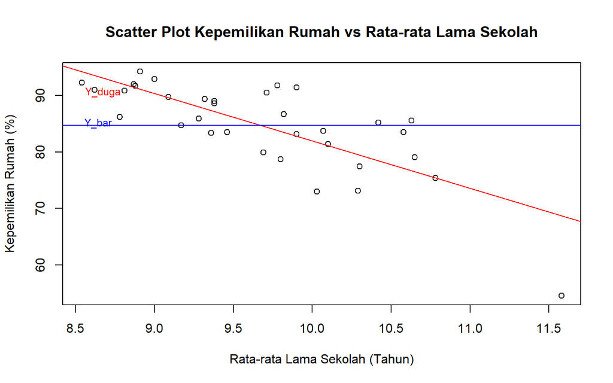

```r
y.bar <- mean(y)
plot(x, y,
     xlab = "Rata-rata Lama Sekolah (Tahun)",
     ylab = "Kepemilikan Rumah (%)",
     main = "Scatter Plot Kepemilikan Rumah vs Rata-rata Lama Sekolah")
abline(model, col="red")
text(min(x), max(y)-2, "Y_duga", adj = c(-0.1, 1.5), col = "red", cex = 0.8)
abline(h=y.bar, col="blue")
text(min(x), y.bar+2, "Y_bar", adj = c(-0.1, 1.5), col = "blue", cex = 0.8)
```

Dari scatter plot di atas, teramati adanya amatan yang menyimpang relatif terhadap nilai harapannya. Penyimpangan amatan dari nilai harapannya inilah yang disebut sebagai galat. Keragaman dari galat tiap amatan ini dapat diurai berdasarkan garis dugaan persamaan ($\hat{Y}$) dan garis rataan nilai responnya ($\bar{Y}$). Penguraian keragaman ini dapat dituliskan sebagai Jumlah Kuadrat Regresi (JKR), Jumlah Kuadrat Galat (JKG), dan Jumlah Kuadrat Total (JKT) dengan perhitungan sebagai berikut.

$$\text{JKR} = \sum_{i=1}^{n} (\hat{y}_i -
\bar{y})^2 ; \text{JKG} = \sum_{i=1}^{n} (y_i - \hat{y})^2 ; \text{JKT}
= \sum_{i=1}^{n} (y_i - \bar{y})^2$$
Hubungan antara ketiganya dapat pula dituliskan sebagai berikut.

$$JKT = JKR + JKG$$
Nilai penguraian keragaman ini dapat diamati pula menggunakan fungsi anova pada bagian **Sum Sq (Jumlah Kuadrat)** seperti yang ditampilkan di bawah. Pada output sintaks di bawah, JKR model bernilai 1191.503 dan JKG model bernilai 849.484.

```r
(anova.model <- anova(model))
```

```
## Analysis of Variance Table
##
## Response: y
##           Df  Sum Sq Mean Sq F value    Pr(>F)
## x          1 1191.50 1191.50  44.884 1.456e-07 ***
## Residuals 32  849.48   26.55
## ---
## Signif. codes:  0 '***' 0.001 '**' 0.01 '*' 0.05 '.' 0.1 ' ' 1
```

Dari tabel ANOVA dan penguraian keragaman, dapat diduga pula ragam galat/error dari model yang kita peroleh. Secara umum, error dari model dapat diduga oleh nilai Kuadrat Tengah Galat (KTG) sehingga berdasarkan output sintaks di atas, diketahui bahwa ragam galat dari model bernilai 26.546. Hubungan antara keduanya dapat dituliskan sebagai berikut.

$$\sigma^2_e = S_{e}^2= \text{KTG} =
\frac{\text{JKG}}{n-2}$$

```r
(KTG <- anova.model$`Mean Sq`[2])
```

```
## [1] 26.54639
```

Dari nilai dugaan ragam galat di atas, dapat diduga pula nilai dugaan dari simpangan bakunya. Dugaan simpangan baku inilah yang disebut sebagai galat baku. Hubungan antara galat baku dan ragam galat dapat dituliskan sebagai berikut.

$$S_e = \sqrt{S_{e}^2}$$

Oleh karena simpangan baku merupakan akar kuadrat dari ragam, maka nilai dugaan galat baku model yang kita bentuk adalah $S_e = \sqrt{26.5464} \approx 5.1523$

```r
(galat.baku <- sqrt(KTG))
```

```
## [1] 5.152319
```

# Keragaman Dugaan Parameter

## Dugaan Parameter $\beta_0$

Sebelumnya, melalui fungsi `lm` dan perhitungan manual yang sudah dibahas pada pertemuan sebelumnya, kita sudah mendapatkan nilai dugaan parameter β0 dan β1 sebesar 165.8212 dan -8.3870. Kedua nilai dugaan parameter tersebut dapat kita definisikan sebagai berikut.

```r
(b0 <- model$coefficients[[1]])
```

```
## [1] 165.8212
```

```r
(b1 <- model$coefficients[[2]])
```

```
## [1] -8.387017
```

Selanjutnya kita dapat menghitung nilai ragam dan t-hitung dari dugaan parameter $β_0$ tersebut dengan perhitungan sebagai berikut.

$$\text{S}_{\hat{\beta_0}} = \sqrt{KTG
\left[\frac{1}{n} + \frac{\bar{X}^2}{\sum_{i=1}^{n}(X_i -
\bar{X})^2}\right]} ; t_{h} = \frac{\hat{\beta_0} -
\beta_0}{S_{\hat{\beta_0}}}$$
Nilai $\text{S}_{\hat{\beta_0}}$ dapat dihitung dengan sintaks sebagai berikut

```r
(se_b0 <- sqrt(KTG*(1/n+mean(x)^2/sum((x-mean(x))^2))))
```

```
## [1] 12.14156
```

Jika dalam uji hipotesis kita ingin menguji apakah $\beta_0$, maka nilai th dapat dihitung sebagai berikut.

```r
uji <- 0
(t_b0 <- (b0 - uji)/se_b0)
```

```
## [1] 13.65733
```

```r
abs(qt(0.025, df = n-2))
```

```
## [1] 2.036933
```

## Dugaan Parameter $\beta_1$

Sementara itu, ragam dan t-hitung dari dugaan parameter $\beta_1$ dapat diperoleh dari perhitungan berikut.

$$\text{S}_{\hat{\beta_1}} =
\sqrt{\frac{KTG}{\sum_{i=1}^{n}(x_i - \bar{x})^2}} ; t_{h} =
\frac{\hat{\beta_1} - \beta_1}{S_{\hat{\beta_1}}}$$

Nilai $\text{S}_{\hat{\beta_1}}$ dapat dihitung dengan sintaks sebagai berikut

```r
(se_b1 <- sqrt(KTG/sum((x-mean(x))^2)))
```

```
## [1] 1.25188
```

Jika dalam uji hipotesis kita ingin menguji apakah $\beta_1 = 0$, maka nilai $t_h$ dapat dihitung sebagai berikut.

```r
uji <- 0
(t_b1 <- (b1 - uji)/se_b1)
```

```
## [1] -6.699539
```

```r
abs(qt(0.025, df = n-2))
```

```
## [1] 2.036933
```

# Selang Kepercayaan Parameter

Secara umum, kita dapat memahami bahwa selang kepercayaan untuk $β_0$ dan $β_1$ terdiri atas batas bawah dan batas atas yang dapat dituliskan sebagai berikut.

$$\text{Selang Kepercayaan } \beta_0 :
\hat{\beta_0} \pm t_{\alpha/2, n-2} S_{\hat{\beta_0}}$$
$$\text{Selang Kepercayaan } \beta_1 :
\hat{\beta_1} \pm t_{\alpha/2, n-2} S_{\hat{\beta_1}}$$

Dengan menggunakan tingkat signifikansi $α = 0,05$, maka nilai $t_{α/2,n-2}$ dapat dihitung sebagai berikut.

```r
t_table <- abs(qt(0.025, df = n-2))
t_table
```

```
## [1] 2.036933
```

Selanjutnya, selang kepercayaan untuk parameter $β_0$ dan $β_1$ dapat dihitung sebagai berikut.

```r
# Selang kepercayaan beta0
lower_b0 <- b0 - t_table * se_b0
upper_b0 <- b0 + t_table * se_b0
cat("Selang kepercayaan beta0: [", lower_b0, ", ", upper_b0, "]\n")
```

```
## Selang kepercayaan beta0: [ 141.0897 ,  190.5528 ]
```

```r
# Selang kepercayaan beta1
lower_b1 <- b1 - t_table * se_b1
upper_b1 <- b1 + t_table * se_b1
cat("Selang kepercayaan beta1: [", lower_b1, ", ", upper_b1, "]\n")
```

```
## Selang kepercayaan beta1: [ -10.93701 ,  -5.837021 ]
```

Sehingga dapat disimpulkan bahwa pada taraf signifikansi 5%, selang kepercayaan untuk parameter $β_0$ adalah [141.089 , 190.553] dan untuk parameter $β_1$ adalah [-10.937 , -5.837].

# Selang Kepercayaan

## Bagi Nilai Rataan/Nilai Harapan Amatan

Secara umum, kita dapat memahami bahwa selang kepercayaan untuk $E(\hat{Y}|X=x_0)$ terdiri atas batas bawah dan batas atas yang dapat dituliskan sebagai berikut.
$$E(\hat{Y}|X=x_0) \pm t_{\alpha/2, n-2} S_e
\sqrt{(\frac{1}{n} + \frac{(x_i -
\bar{x})^2}{\sum_{1=1}^n(x_i-\bar{x})^2})}$$
Misalkan kita ingin menduga nilai rataan (harapan) amatan ketika nilai x=10. Kita dapat memanfaatkan fungsi `predict` untuk mendapatkan nilai dugaan dan selang kepercayaannya sebagai berikut.

```r
amatan.diduga <- data.frame(x=10)
predict(model, amatan.diduga, interval = "confidence")
```

```
##        fit      lwr      upr
## 1 81.95107 79.96737 83.93477
```

Berdasarkan output sintaks di atas, diketahui bahwa dugaan rataan nilai $Y$ ketika nilai x=10 adalah 81.951. Selain itu, diindikasikan juga bahwa dalam taraf kepercayaan 95%, diyakini bahwa nilai dugaan rataan $Y$ ketika nilai x=10 berada dalam selang 79.967 hingga 83.935.

## Bagi Individu amatan

Secara umum, kita dapat memahami bahwa selang kepercayaan untuk $\hat{y}(s_i)$terdiri atas batas bawah dan batas atas yang dapat dituliskan sebagai berikut.

$$\hat{y}(x_i)\pm t_{\alpha/2, n-2} S_e
\sqrt{1+(\frac{1}{n} + \frac{(x_i -
\bar{x})^2}{\sum_{1=1}^n(x_i-\bar{x})^2})}$$

Misalkan kita ingin menduga nilai individu amatan ketika nilai x=10. Kita dapat memanfaatkan fungsi `predict` untuk mendapatkan nilai dugaan dan selang kepercayaannya sebagai berikut.

```r
predict(model, amatan.diduga, interval = "prediction")
```

```
##        fit      lwr      upr
## 1 81.95107 71.27031 92.63183
```

Berdasarkan output sintaks di atas, diketahui bahwa dugaan nilai individu Y ketika nilai x=10 adalah 81.951. Selain itu, diindikasikan juga bahwa dalam taraf kepercayaan 95%, diyakini bahwa nilai amatan individu Y ketika nilai x=10 berada dalam selang 71.270 hingga 92.632.